# 3. Logistic Regression

*This chapter consist of exercises related data wrangling and analysis.* However, the code for data wrangling is not presented here as instructed, please see it at the github repository. After some house keeping, the exercise is divided to 8 parts. The contents of these parts are introduced in the beginning of each part (and the headers are quite informative too). First part refers to creating this .Rmd-file, so I start with part 2 in the analysis. The topic of this chapter is logistic regression, where the dependent (target) variable is discrete.

I start with some house keeping and calling the packages used later in the exercise.

```r
rm(list=ls())
library(dplyr)
```

```r
library(ggplot2)
library(GGally)
library(tidyr)
```

## Part 2: Importing data + brief overview

First thing here is to import the joined student alcohol consumption data, after which I print out the names of the variables in the data and describe the data set briefly.

```r
alc <- read.table("alc.txt", sep=",")
#names of variables
names(alc)
```

```
##  [1] "school"     "sex"        "age"        "address"    "famsize"
##  [6] "Pstatus"    "Medu"       "Fedu"       "Mjob"       "Fjob"
## [11] "reason"     "nursery"    "internet"   "guardian"   "traveltime"
## [16] "studytime"  "failures"   "schoolsup"  "famsup"     "paid"
## [21] "activities" "higher"     "romantic"   "famrel"     "freetime"
## [26] "goout"      "Dalc"       "Walc"       "health"     "absences"
## [31] "G1"         "G2"         "G3"         "alc_use"    "high_use"
```

```r
#for curiosity, dimensions and structure:
#dimensions of the data
dim(alc)
```

```
## [1] 382  35
```

```r
# look at the structure of the data
str(alc)
```

```
## 'data.frame':    382 obs. of  35 variables:
##  $ school    : Factor w/ 2 levels "GP","MS": 1 1 1 1 1 1 1 1 1 1 ...
##  $ sex       : Factor w/ 2 levels "F","M": 1 1 1 1 1 2 2 1 2 2 ...
##  $ age       : int  18 17 15 15 16 16 16 17 15 15 ...
##  $ address   : Factor w/ 2 levels "R","U": 2 2 2 2 2 2 2 2 2 2 ...
##  $ famsize   : Factor w/ 2 levels "GT3","LE3": 1 1 2 1 1 2 2 1 2 1 ...
##  $ Pstatus   : Factor w/ 2 levels "A","T": 1 2 2 2 2 2 2 1 1 2 ...
##  $ Medu      : int  4 1 1 4 3 4 2 4 3 3 ...
##  $ Fedu      : int  4 1 1 2 3 3 2 4 2 4 ...
##  $ Mjob      : Factor w/ 5 levels "at_home","health",..: 1 1 1 2 3 4 3 3 4 3 ...
##  $ Fjob      : Factor w/ 5 levels "at_home","health",..: 5 3 3 4 3 3 3 5 3 3 ...
##  $ reason    : Factor w/ 4 levels "course","home",..: 1 1 3 2 2 4 2 2 2 2 ...
##  $ nursery   : Factor w/ 2 levels "no","yes": 2 1 2 2 2 2 2 2 2 2 ...
##  $ internet  : Factor w/ 2 levels "no","yes": 1 2 2 2 1 2 2 1 2 2 ...
##  $ guardian  : Factor w/ 3 levels "father","mother",..: 2 1 2 2 1 2 2 2 2 2 ...
```

[output cut: 21 more lines]

The dataset “alc” includes 382 rows (observations) and 35 columns (variables). The types of variables can be checked from output of str(alc). Most of them are factors and integers with the exceptions of “alc_use” (num) and “high_use” (logical). The names of the variables are listed above. The dataset was imported from working directory as “alc.txt” was created earlier in the data wrangling part.

The original dataset is described as follows: “This data approach student achievement in secondary education of two Portuguese schools. The data attributes include student grades, demographic, social and school related features) and it was collected by using school reports and questionnaires. Two datasets are provided regarding the performance in two distinct subjects: Mathematics (mat) and Portuguese language (por).” (https://archive.ics.uci.edu/ml/datasets/Student+Performance)"

In short, the dataset is a combination of two sets and it contains results of a questionnaire that is later used to study the relationship between alcohol consumption and school performance among other things while taking account various aspects listed above. (Please note that some of the more detailed description of variables and data is provided later in Part 4!)

### Source of the data

The source of the data: https://archive.ics.uci.edu/ml/machine-learning-databases/00320/ (Paulo Cortez, University of Minho, GuimarÃ£es, Portugal, http://www3.dsi.uminho.pt/pcortez) (more information about the data: https://archive.ics.uci.edu/ml/datasets/Student+Performance) The dataset “alc” used in this chapter is wrangled from the source mentioned above.

## Part 3: Hypotheses about relationships between various variables and high alcohol consumption

In this part I briefly speculate about 4 variables having a relationship with high alcohol consumption. Below I present 4 hypothesis. Disclaimer: the hypothesis are to give only some reasoning about the relationship and they are not intended to cover all the relevant mechanisms as it wasn’t the task here.

- “absences”: I expect high alcohol consumption to have a positive relationship with the number of school absences as consuming alcohol causes hangover, which makes it less pleasant to go to school. Also, choosing to consume a lot of alcohol indicates that the student’s preferences are heavily affected by instant gratifications as he/she is willing to sacrifice tomorrows utility for today’s utility. Using the same logic, as going to school could be interpreted as sacrificing todays’s utility for tomorrow’s, I’d expect the alcohol-preferring student to skip school.
- “famrel”: I expect that family relations have a negative correlation with high alcohol consumption as good family relations could mean that the parents protect the student from using alcohol and as bad relationships with family may be a driver for consuming alcohol and not being at home.
- “G3”: I expect grades to have a negative relationship with high alcohol consumption as consuming alcohol is associated with worse skills in coping with delayed gratification and as high alcohol consumption causes hangovers which makes it harder to study for exams etc.
- “failures”: This is a similar variable as “G3” and “absences” in the way that I expect high alcohol consumption to have a negative relationship with performance in school: thus, I expect a positive relationship with number of past class failures and high alcohol consumption as consumption may signal low motivation for various reasons, cause hangovers that affect performance etc.

## Part 4: Numerical and graphical exploration of distributions of variables and their relationships with alcohol consumption

I use a subset of the full dataset here to illustrate the relationships between the dependent and my choosing of independent variables. To use a subset, I create a data frame called “minialc” from the original “alc” so that I get to study the vatiables of interest and their relationships.

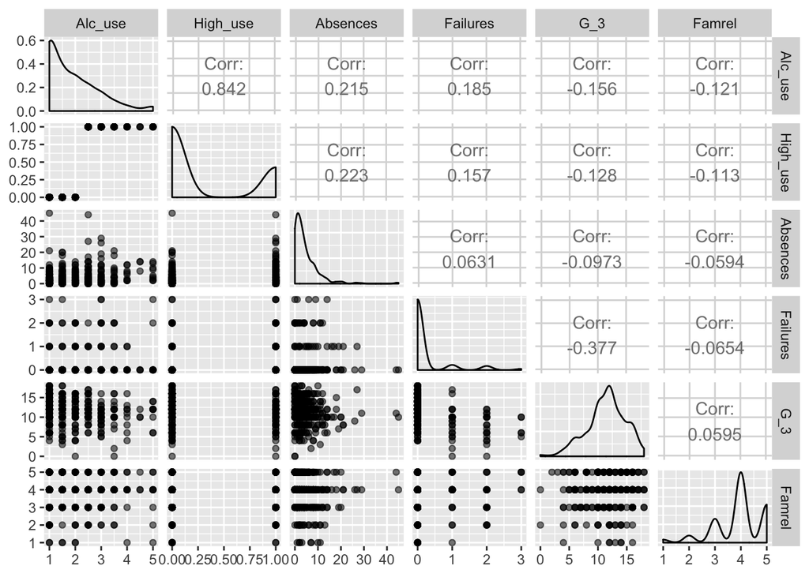

```r
Alc_use<-alc$alc_use
High_use<-alc$high_use
Absences<-alc$absences
Failures<-alc$failures
G_3<-alc$G3
Famrel<-alc$famrel
mini<-cbind(Alc_use, High_use, Absences, Failures, G_3, Famrel)
minialc<-as.data.frame(mini)
p <- ggpairs(minialc, mapping = aes(alpha=0.3), lower = list(combo = wrap("facethist", bins = 20)))
p
```

Studying this correlogram reveals quite a bit. I start with the interpretation of graphical distributions.

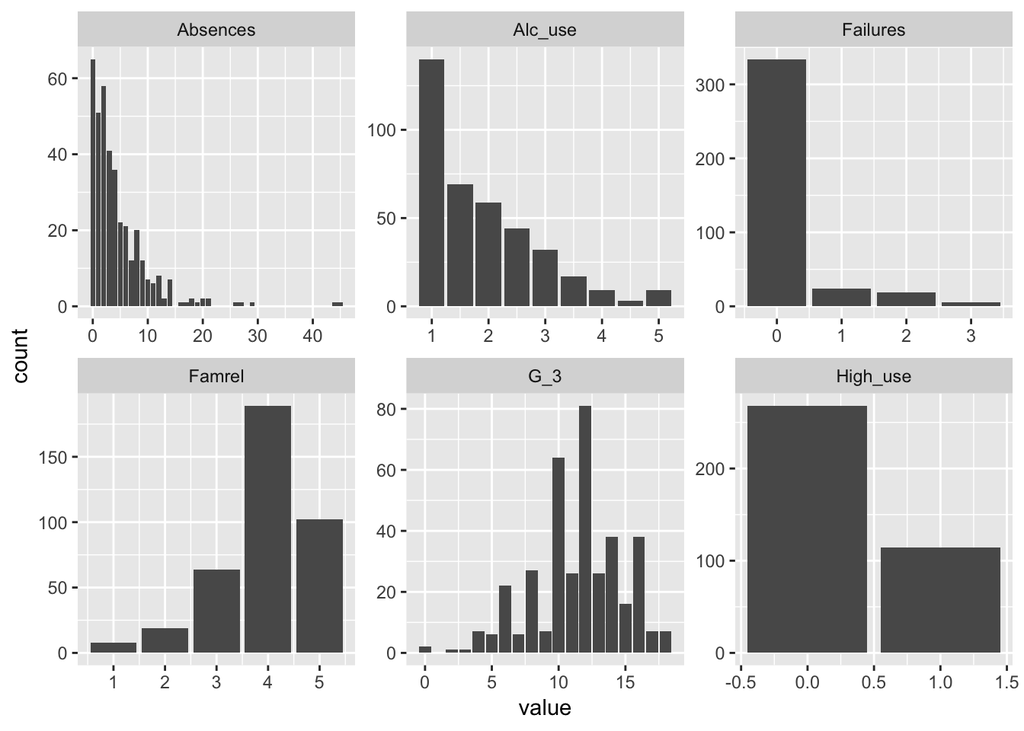

```r
gather(minialc) %>% ggplot(aes(value)) + facet_wrap("key", scales = "free")+geom_bar()
```

**Numerically, the correlogram shows that the direction of my hypothesis in part 3 were correct.**

However, what is surprising in my opinion, is that the correlations with “Alc_use”" were fairly small in absolute values. Absences has clearly highest correlation (in absolute values) with alcohol usage (0.215) while others are way smaller (Failures 0.185, G_3 -0.156, Famrel -0.121).

## Part 5: Statistical analysis: logistic regression

In this part, I use logistic regression to statistically explore the relationship between my choosing of dependent variables (Failures, Famrel, G_3, Asences) and the binary high/low alcohol consumption variable as the target variable. I present and interpret a summary of the fitted model and the coefficients of the model, and I provide confidence intervals for them. Results are presented and compared with respect to my hypothesis stated in Part 3.

```r
m <- glm(high_use ~ failures + absences + famrel + G3, data = alc, family = "binomial")
summary(m)
```

```
##
## Call:
## glm(formula = high_use ~ failures + absences + famrel + G3, family = "binomial",
##     data = alc)
##
## Deviance Residuals:
##     Min       1Q   Median       3Q      Max
## -2.2195  -0.7992  -0.6770   1.1782   1.9915
##
## Coefficients:
##             Estimate Std. Error z value Pr(>|z|)
## (Intercept)  0.02926    0.67814   0.043 0.965585
## failures     0.39080    0.19830   1.971 0.048752 *
## absences     0.08174    0.02253   3.628 0.000285 ***
## famrel      -0.22402    0.12525  -1.789 0.073669 .
## G3          -0.04377    0.03794  -1.154 0.248623
## ---
## Signif. codes:  0 '***' 0.001 '**' 0.01 '*' 0.05 '.' 0.1 ' ' 1
##
## (Dispersion parameter for binomial family taken to be 1)
##
##     Null deviance: 465.68  on 381  degrees of freedom
## Residual deviance: 435.52  on 377  degrees of freedom
## AIC: 445.52
##
## Number of Fisher Scoring iterations: 4
```

Summary of our model shows that among our explanatory variables, only “absences” and “failures” have a statistically significant relationship with “high_use” (p<0.05 -> null hypothesis of coef=0 can be rejected). They also have positive coefficients matching with the hypothesis while “famrel” and “G3” don’t have statistical significance although the negative coefficients match with the hypothesis.

```r
# compute odds ratios (OR)
OR <- coef(m) %>% exp

# compute confidence intervals (CI)
CI <- confint(m) %>% exp
# print out the odds ratios with their confidence intervals
cbind(OR, CI)
```

```
##                    OR     2.5 %   97.5 %
## (Intercept) 1.0296913 0.2699340 3.891344
## failures    1.4781653 1.0018560 2.193923
## absences    1.0851775 1.0405060 1.136808
## famrel      0.7992957 0.6247181 1.022647
## G3          0.9571760 0.8883867 1.031268
```

Studying the Odds ratios (“OR” in the table above) informs us that as failures and absences have an OR higher than 1 (1.47 and 1.08, respectively), they are positively associated with high use of alcohol, while ORs lower than one for famrel and G3 are interpreted as they being negatively associated with high use of alcohol. In other words, and being a bit more accurate, the ORs are interpreted as follows: if student has failures, he/she is 1.48 times more likely to consume high amounts of alcohol compared to someone without failures. Other ORs are interpreted accordingly, for example, if a student has a good relationship with his/her family, he is less likely (OR = 0.8 <1) to consume high amounts of alcohol and if a student has high grades (G3), he/she is less likely (0.96 < 1) to consume high amounts of alcohol. NB: “famrel” and “G3” were not statistically significant at p<0.05.

## Part 6: Exploring the predictive power of the model

This part focuses on analysing the predictive power of our new model in which we have dropped “famrel” and “G3” as they were not statistically significant.

```r
# fit the model with only significant variables
m <- glm(high_use ~ failures + absences, data = alc, family = "binomial")

# predict() the probability of high_use
probabilities <- predict(m, type = "response")

# add the predicted probabilities to 'alc'
alc <- mutate(alc, probability = probabilities)

# use the probabilities to make a prediction of high_use
alc <- mutate(alc, prediction = probability > 0.5)

# see the last ten original classes, predicted probabilities, and class predictions
select(alc, failures, absences, sex, high_use, probability, prediction) %>% tail(10)
```

```
##     failures absences sex high_use probability prediction
## 373        1        0   M    FALSE   0.2934743      FALSE
## 374        1        7   M     TRUE   0.4313255      FALSE
## 375        0        1   F    FALSE   0.2154691      FALSE
## 376        0        6   F    FALSE   0.2968841      FALSE
## 377        1        2   F    FALSE   0.3303652      FALSE
## 378        0        2   F    FALSE   0.2303651      FALSE
## 379        2        2   F    FALSE   0.4484793      FALSE
## 380        0        3   F    FALSE   0.2459680      FALSE
## 381        0        4   M     TRUE   0.2622677      FALSE
## 382        0        2   M     TRUE   0.2303651      FALSE
```

```r
# tabulate the target variable versus the predictions
table(high_use = alc$high_use, prediction = alc$prediction)
```

```
##         prediction
## high_use FALSE TRUE
##    FALSE   258   10
##    TRUE     99   15
```

Above in our confusion matrix, which shows predictions versus the actual values. Below is a graphical visualization of both the actual values and the predictions.

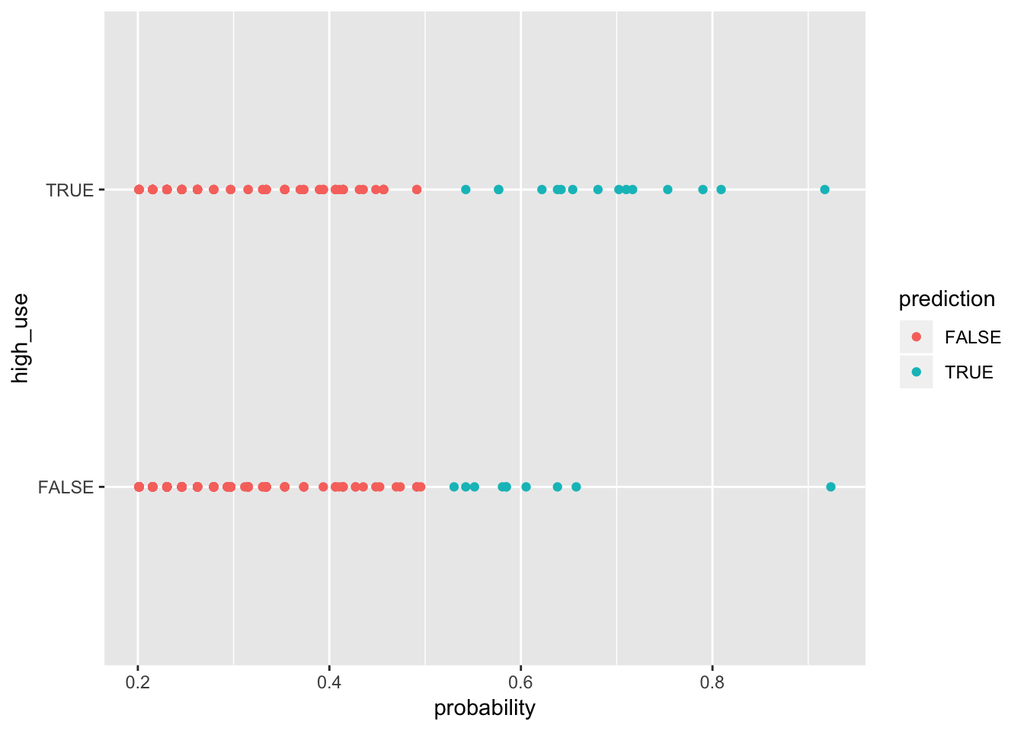

```r
# initialize a plot of 'high_use' versus 'probability' in 'alc'
g <- ggplot(alc, aes(x = probability, y = high_use,col=prediction))

# define the geom as points and draw the plot
g+geom_point()
```

```r
# tabulate the target variable versus the predictions
table(high_use = alc$high_use, prediction = alc$prediction)%>%prop.table%>%addmargins
```

```
##         prediction
## high_use      FALSE       TRUE        Sum
##    FALSE 0.67539267 0.02617801 0.70157068
##    TRUE  0.25916230 0.03926702 0.29842932
##    Sum   0.93455497 0.06544503 1.00000000
```

## Part 7: Bonus: 10-fold cross-validation

```r
# define a loss function (average prediction error)
loss_func <- function(class, prob) {
  n_wrong <- abs(class - prob) > 0.5
  mean(n_wrong)
}

# compute the average number of wrong predictions in the (training) data
loss_func(alc$high_use, alc$probability)
```

```
## [1] 0.2853403
```

```r
# 10-fold cross-validation
library(boot)
cv <- cv.glm(data = alc, cost = loss_func, glmfit = m, K = 10)

# average number of wrong predictions in the cross validation
cv$delta[1]
```

```
## [1] 0.2853403
```

Comparing this to the results in DataCamp-exercise, my model has worse test set performance (bigger prediction error using 10-fold cross-validation) compared to the model introduced in DataCamp (which had about 0.26 error).

Next I try to see if I could find a model with smaller prediction error than 0.26 using a larger model. I do this by adding some variables to my original model, namely “famrel”, “G3”, “guardian”, “sex”, “higher”, “Pstatus”, “Medu” and “Fedu”.

```r
# fit the model with only significant variables
m2 <- glm(high_use ~ failures + absences + famrel + G3+ guardian + sex + higher + Pstatus + Medu + Fedu, data = alc, family = "binomial")
cv2 <- cv.glm(data = alc, cost = loss_func, glmfit = m2, K = 10)
cv2$delta[1]
```

```
## [1] 0.2696335
```

With this larger model, depending on the simulation, I get average number of wrong predictions in the 10-fold cross-validation from approximately 0.253 to 0.272, so it is not clear if this model performs better in prediction than the DataCamp model. In some simulations it does, and it performs better than my original model at least.

(((This implies that our model generalizes fairly well to independent data set as the difference in our average prediction error with the training data doesn’t differ much from the estimated wrong predictions in our cross-validation. In other words, our predictive model does relatively well in practice (=unseen data).)))

## Part 8: Super-Bonus: Perform cross-validation to compare the performance of different logistic regression models (= different sets of predictors).

In this section I fit different numbers of variables to my logistic model and perform same analysis round after round dropping one variable every time. Then I compare the performance of these models in terms of the 10-fold cross-validation. First, I create the new models and calculate the estimated wrong predictions and then I plot this to graphically see if there is a trend.

```r
m10 <- glm(high_use ~ failures + absences + famrel + G3+ guardian + sex + higher + Pstatus + Medu + Fedu, data = alc, family = "binomial")
cv10 <- cv.glm(data = alc, cost = loss_func, glmfit = m10, K = 10)
pe10<-cv10$delta[1]
pe10
```

```
## [1] 0.2670157
```

```r
m9 <- glm(high_use ~ failures + absences + famrel + G3+ guardian + sex + higher + Pstatus + Medu, data = alc, family = "binomial")
cv9 <- cv.glm(data = alc, cost = loss_func, glmfit = m9, K = 10)
pe9<-cv9$delta[1]
pe9
```

```
## [1] 0.2748691
```

```r
m8 <- glm(high_use ~ failures + absences + famrel + G3+ guardian + sex + higher + Pstatus, data = alc, family = "binomial")
cv8 <- cv.glm(data = alc, cost = loss_func, glmfit = m8, K = 10)
pe8<-cv8$delta[1]
pe8
```

```
## [1] 0.2801047
```

```r
m7 <- glm(high_use ~ failures + absences + famrel + G3+ guardian + sex + higher, data = alc, family = "binomial")
cv7 <- cv.glm(data = alc, cost = loss_func, glmfit = m7, K = 10)
pe7<-cv7$delta[1]
pe7
```

```
## [1] 0.2774869
```

```r
m6 <- glm(high_use ~ failures + absences + famrel + G3+ guardian + sex, data = alc, family = "binomial")
cv6 <- cv.glm(data = alc, cost = loss_func, glmfit = m6, K = 10)
pe6<-cv6$delta[1]
pe6
```

```
## [1] 0.2722513
```

```r
m5 <- glm(high_use ~ failures + absences + famrel + G3+ guardian, data = alc, family = "binomial")
cv5 <- cv.glm(data = alc, cost = loss_func, glmfit = m5, K = 10)
pe5<-cv5$delta[1]
pe5
```

```
## [1] 0.3010471
```

```r
m4 <- glm(high_use ~ failures + absences + famrel + G3, data = alc, family = "binomial")
cv4 <- cv.glm(data = alc, cost = loss_func, glmfit = m4, K = 10)
pe4<-cv4$delta[1]
pe4
```

```
## [1] 0.3010471
```

```r
m3 <- glm(high_use ~ failures + absences + famrel, data = alc, family = "binomial")
cv3 <- cv.glm(data = alc, cost = loss_func, glmfit = m3, K = 10)
pe3<-cv3$delta[1]
pe3
```

```
## [1] 0.2958115
```

```r
m2 <- glm(high_use ~ failures + absences, data = alc, family = "binomial")
cv2 <- cv.glm(data = alc, cost = loss_func, glmfit = m2, K = 10)
pe2<-cv2$delta[1]
pe2
```

```
## [1] 0.2801047
```

```r
m1 <- glm(high_use ~ failures, data = alc, family = "binomial")
cv1 <- cv.glm(data = alc, cost = loss_func, glmfit = m1, K = 10)
pe1<-cv1$delta[1]
pe1
```

```
## [1] 0.3036649
```

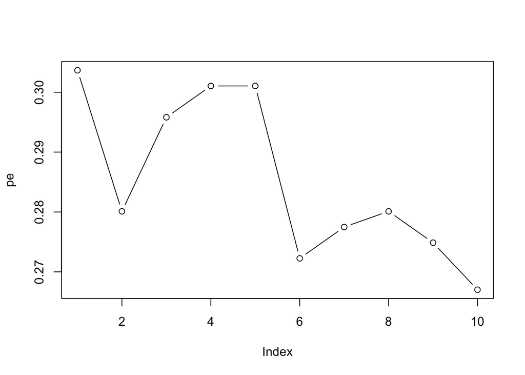

```r
pe<-c(pe1, pe2,pe3, pe4, pe5, pe6,pe7,pe8,pe9,pe10)
x=c(1:10, pe)
plot(pe, type="b")
```

It seems that with a larger number of predictors the average prediction error gets smaller (observation at index = 10 refers to the average prediction error of a model with 10 predictors etc.). The interpretation here would be roughly such that the prediction is more accurate the more variables we fit to our model.

The trend is not linear in the graph as the errors represent a result from a single simulation and maybe repeating the simulations and averaging them could give us a better idea about how the average prediction errors behave with different number of predictors.